# Meeting 12 - ANOVA

Matthew E. Aiello-Lammens

2019-04-24

# Today’s Goals

- Introduction to all things ANOVA
- As time allows:
  - One-way ANOVA
  - Nested ANOVA
  - Factorial / Multi-way ANOVA

# Introduction to Analysis of Variance - ANOVA

In biology there are many times when we are working with **categorical** predictor variables and continuous responses. For example, let’s consider a fertilizer addition experiment, where the growth of some plant species is measured under a fertilizer versus no-fertilizer treatment. Here, the predictor variable (fertilizer addition or not) is a categorical variable.

#### Challenge

We have worked with this kind of simple case, where we have one-predictor variable which can take two values. What did we do in this case?

```r
library(dplyr)
data(iris)
t.test( x = filter(iris, Species == "setosa")$Petal.Length,
        y = filter(iris, Species == "versicolor")$Petal.Length )
```

```
##
##  Welch Two Sample t-test
##
## data:  filter(iris, Species == "setosa")$Petal.Length and filter(iris, Species == "versicolor")$Petal.Length
## t = -39.493, df = 62.14, p-value < 2.2e-16
## alternative hypothesis: true difference in means is not equal to 0
## 95 percent confidence interval:
##  -2.939618 -2.656382
## sample estimates:
## mean of x mean of y
##     1.462     4.260
```

```r
anova(lm(data = filter(iris, Species != "virginica"), formula = Petal.Length ~ Species))
```

```
## Analysis of Variance Table
##
## Response: Petal.Length
##           Df  Sum Sq Mean Sq F value    Pr(>F)
## Species    1 195.720 195.720  1559.7 < 2.2e-16 ***
## Residuals 98  12.298   0.125
## ---
## Signif. codes:  0 '***' 0.001 '**' 0.01 '*' 0.05 '.' 0.1 ' ' 1
```

If we have more than two values within a single predictor variable, then we cannot use a *t*-test. Here we go to an ANOVA.

```r
anova(lm(data = iris, formula = Petal.Length ~ Species))
```

```
## Analysis of Variance Table
##
## Response: Petal.Length
##            Df Sum Sq Mean Sq F value    Pr(>F)
## Species     2 437.10 218.551  1180.2 < 2.2e-16 ***
## Residuals 147  27.22   0.185
## ---
## Signif. codes:  0 '***' 0.001 '**' 0.01 '*' 0.05 '.' 0.1 ' ' 1
```

We’ll work through another example below, that comes from the lecture material.

## Visual understanding of ANOVA

Logan, Figure 10.2, offers a good visual understanding of ANOVA. Note that we are examining the relationships between different sets of sums of squares (think about calculating variance!).

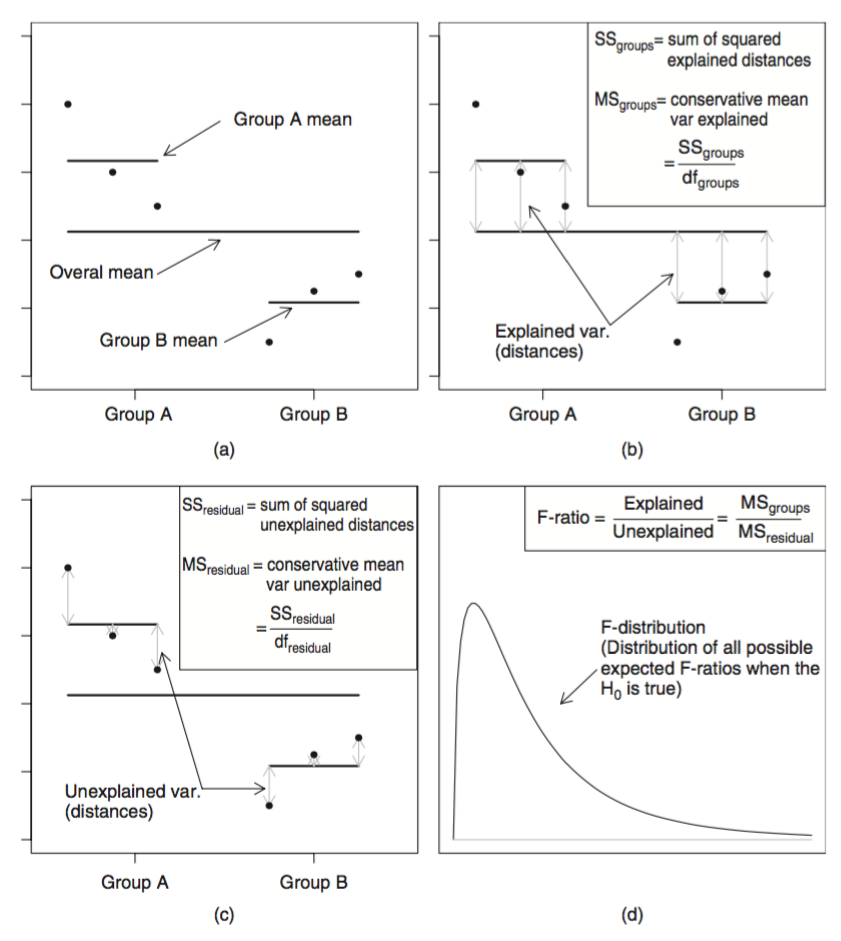

Logan - Figure 10.2

## Fixed versus Random Effects

**Fixed factors** are ones we have manipulated, or that we expect *a priori* to have an effect on the response. From Logan, p 254 - “conclusions about the effects of a fixed factor are restricted to the specific treatment levels investigated …”

**Random factors** are, as per Logan, p. 254, “randomly chosen from all the possible levels of populations and are used as random representatives of the populations”. E.g., density of plants could be random. Or position of camera traps on a hillside.

## Null hypotheses

**Fixed effects model:**

$$H_0: \mu_1 = \mu_2 = ... = \mu_i = \mu$$

**Random effects model:**

$$H_0: \sigma^2_1 = \sigma^2_2 = ... = \sigma^2_i = \sigma^2$$

# One-way ANOVA

Here I will demonstrate how to do an ANOVA in R using the Wolf River data set.

```r
#aldrin <- read.csv("https://www.dropbox.com/s/sfstj4p8beajir5/aldrin.csv?dl=1")
aldrin <- read.csv("https://bit.ly/2DXjm59")
summary(aldrin)
```

```
##      aldrin            depth
##  Min.   :3.100    bottom  :10
##  1st Qu.:4.300    middepth:10
##  Median :4.900    surface :10
##  Mean   :5.097
##  3rd Qu.:5.625
##  Max.   :8.800
```

ANOVA is a kind of linear model (we’ll talk more about this next week), so we use the `lm` function in R first.

```r
aldrin_lm <- lm(data = aldrin, aldrin~depth)
```

Next, we use a special summary command called `anova` to show the results of our linear model.

```r
anova(aldrin_lm)
```

```
## Analysis of Variance Table
##
## Response: aldrin
##           Df Sum Sq Mean Sq F value   Pr(>F)
## depth      2 16.961  8.4803  6.1338 0.006367 **
## Residuals 27 37.329  1.3826
## ---
## Signif. codes:  0 '***' 0.001 '**' 0.01 '*' 0.05 '.' 0.1 ' ' 1
```

## Post-hoc multiple comparisons

We have found that the different locations are different, but not which ones differe frome each other. To do this, we would normally use a method like Tukey’s Honset Significant Differences test, which I implement below.

```r
TukeyHSD(aov(data = aldrin, aldrin~depth))
```

```
##   Tukey multiple comparisons of means
##     95% family-wise confidence level
##
## Fit: aov(formula = aldrin ~ depth, data = aldrin)
##
## $depth
##                     diff       lwr       upr     p adj
##  middepth- bottom  -0.99 -2.293785  0.313785 0.1630654
##  surface- bottom   -1.84 -3.143785 -0.536215 0.0045163
##  surface- middepth -0.85 -2.153785  0.453785 0.2561389
```

Note, that for reasons that have never been clear to me, you can only use the TukeyHSD method when using the `aov` function. For an alternative approach, see the `glht` function in the `multcomp` package. This is described in Logan (e.g., p. 267).

## Planned comparisons

Where as unplanned, post-hoc comparisons require a correction for multiple comparisons, planned comparisons do not. We will not cover planned comparisons in class, but they may show up in the homework or on the final. Example 10B in Logan provides an example of the use of planned comparisons.

# Nested ANOVA

Sometimes your replicates aren’t quite independent.

Figure 11.1 in Logan provides a good visual of nested design.

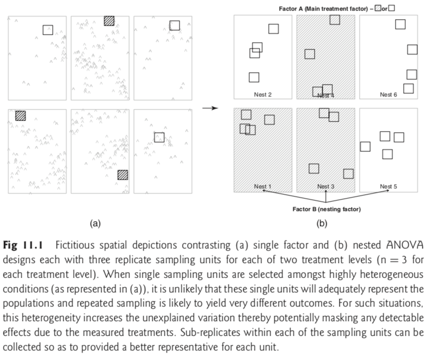

Logan - Figure 11.1

For formula, see Logan p. 284 and for calculation of F-ratios see Table 11.1. **Note that Mean-Squared Errors are the same if B is random or fixed, but F-ratio is differen! Why? Discuss.**

## Unbalanced designes

Often your observations will not be clean. This is unfortunate, as it makes the analyses more complicated. But they are still doable.

## Nested ANOVA Example

From Logan Example 11.A - Density-dependent grazing effects of sea urchin on filamentous algea (Andrew and Underwood 1993).

Levels: 1. Sea urchin density 2. Patches of Reef 3. Quadrats within patches

Get the data and have a look.

```r
#algae_density <- read.csv(file = "https://mlammens.github.io/ENS-623-Research-Stats/data/Logan_Examples/Chapter11/Data/andrew.csv")
algae_density <- read.csv(file = "https://bit.ly/2Dpwr5B")

head(algae_density)
```

```
##   TREAT PATCH QUAD ALGAE
## 1    0%     1    1    46
## 2    0%     1    2    44
## 3    0%     1    3    41
## 4    0%     1    4    29
## 5    0%     1    5    11
## 6    0%     2    1    65
```

```r
summary(algae_density)
```

```
##   TREAT        PATCH            QUAD       ALGAE
##  0%  :20   Min.   : 1.00   Min.   :1   Min.   : 0.00
##  100%:20   1st Qu.: 4.75   1st Qu.:2   1st Qu.: 0.00
##  33% :20   Median : 8.50   Median :3   Median : 5.00
##  66% :20   Mean   : 8.50   Mean   :3   Mean   :20.26
##            3rd Qu.:12.25   3rd Qu.:4   3rd Qu.:41.00
##            Max.   :16.00   Max.   :5   Max.   :83.00
```

Patch and Quad need to be converted to factors!

```r
algae_density$PATCH <- factor(algae_density$PATCH)
algae_density$QUAD <- factor(algae_density$QUAD)

summary(algae_density)
```

```
##   TREAT        PATCH    QUAD       ALGAE
##  0%  :20   1      : 5   1:16   Min.   : 0.00
##  100%:20   2      : 5   2:16   1st Qu.: 0.00
##  33% :20   3      : 5   3:16   Median : 5.00
##  66% :20   4      : 5   4:16   Mean   :20.26
##            5      : 5   5:16   3rd Qu.:41.00
##            6      : 5          Max.   :83.00
##            (Other):50
```

Much better.

Let’s make some visuals.

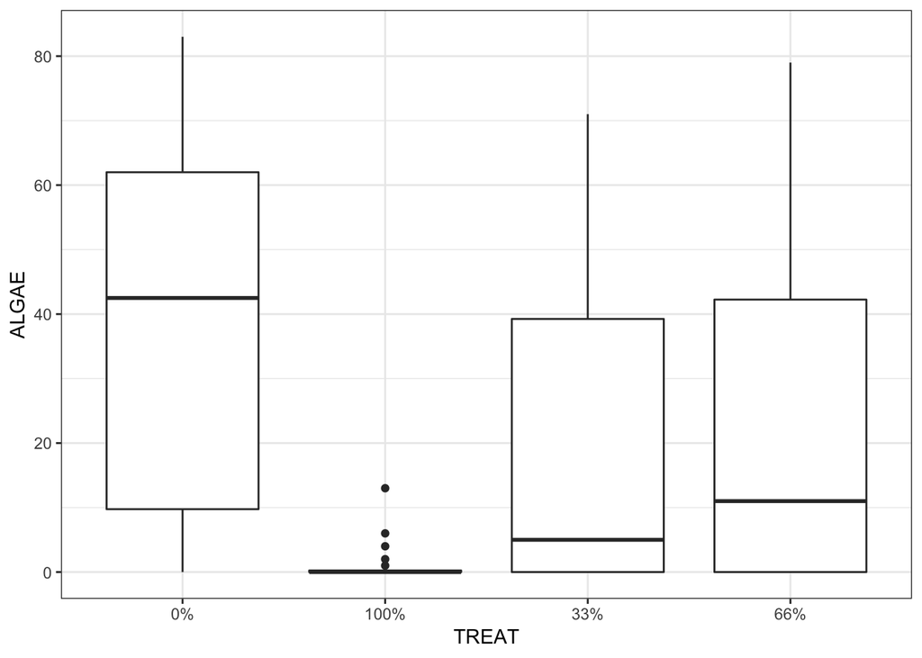

```r
library(ggplot2)

ggplot(data = algae_density) +
  geom_boxplot(aes(x = TREAT, y = ALGAE)) +
  theme_bw()
```

We should also consider this from the perspective to collapsing the quadrats into their mean values.

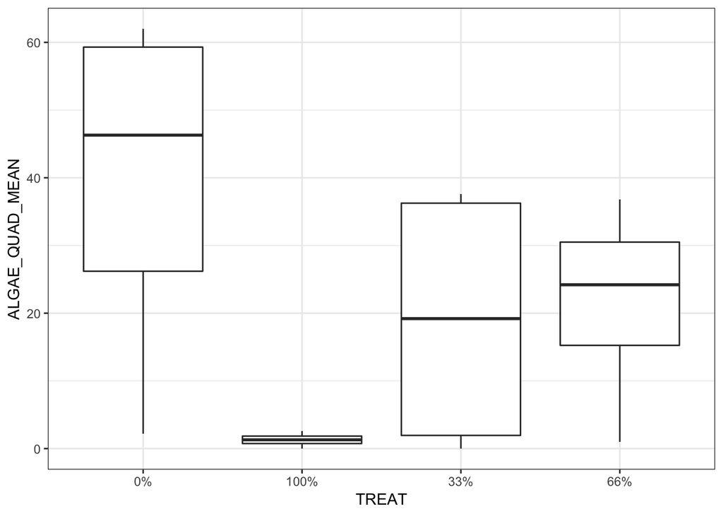

```r
library(dplyr)

algae_density_agg <-
  algae_density %>%
  group_by(TREAT, PATCH) %>%
  summarize(ALGAE_QUAD_MEAN = mean(ALGAE))

ggplot(data = algae_density_agg) +
  geom_boxplot(aes(x = TREAT, y = ALGAE_QUAD_MEAN)) +
  theme_bw()
```

Construct an ANOVA model and look at the results.

```r
algae_density_aov <- aov(data = algae_density, ALGAE ~ TREAT + Error(PATCH))

summary(algae_density_aov)
```

```
##
## Error: PATCH
##           Df Sum Sq Mean Sq F value Pr(>F)
## TREAT      3  14429    4810   2.717 0.0913 .
## Residuals 12  21242    1770
## ---
## Signif. codes:  0 '***' 0.001 '**' 0.01 '*' 0.05 '.' 0.1 ' ' 1
##
## Error: Within
##           Df Sum Sq Mean Sq F value Pr(>F)
## Residuals 64  19110   298.6
```

- What can we conclude?
- What was the unit of replication?

# Factorial ANOVA

What if we want to look at two, or more, factors where one is not nested in the other?

**See visuals as per Logan, Fig 12.1 and 12.2.**

For formula, see Logan p. 314 and for calculation of F-ratios see Table 12.1.

## Example - Two factor fixed effects model (Model I)

From Logan 2010, p. 334:

> Quinn (1988) manipulated the density of adults limpets within enclosures (8, 15, 30 and 45 individuals per enclosure) during two seasons (winter-spring and summer-autumn) so as to investigate the effects of adult density and season on egg mass production by intertidal limpets. Three replicate enclosures per density/season combination were used, and both density and season were considered fixed factors (from Box 9.4 of Quinn and Keough (2002)).

```r
#limpets <- read.csv(file = "https://mlammens.github.io/ENS-623-Research-Stats/data/Logan_Examples/Chapter12/Data/quinn.csv")
limpets <- read.csv(file = "https://bit.ly/2UCV7x2")

head(limpets)
```

```
##   DENSITY SEASON  EGGS
## 1       8 spring 2.875
## 2       8 spring 2.625
## 3       8 spring 1.750
## 4       8 summer 2.125
## 5       8 summer 1.500
## 6       8 summer 1.875
```

```r
summary(limpets)
```

```
##     DENSITY         SEASON        EGGS
##  Min.   : 8.00   spring:12   Min.   :0.3560
##  1st Qu.:13.25   summer:12   1st Qu.:0.9165
##  Median :22.50               Median :1.4330
##  Mean   :24.50               Mean   :1.4717
##  3rd Qu.:33.75               3rd Qu.:1.9227
##  Max.   :45.00               Max.   :2.8750
```

```r
limpets$DENSITY <- factor(limpets$DENSITY)
```

Let’s get some visuals.

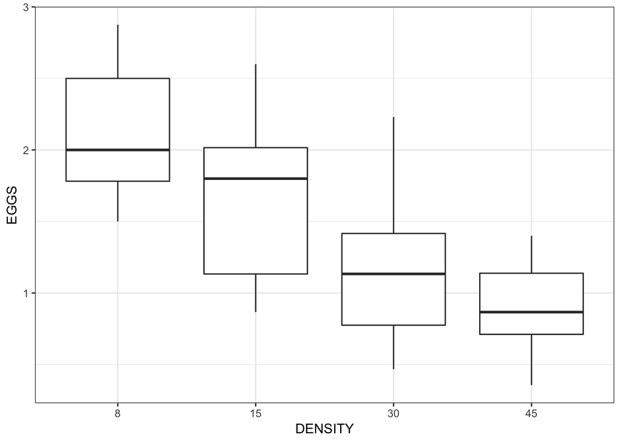

```r
ggplot(data = limpets) +
  geom_boxplot(aes(x = DENSITY, y = EGGS)) +
  theme_bw()
```

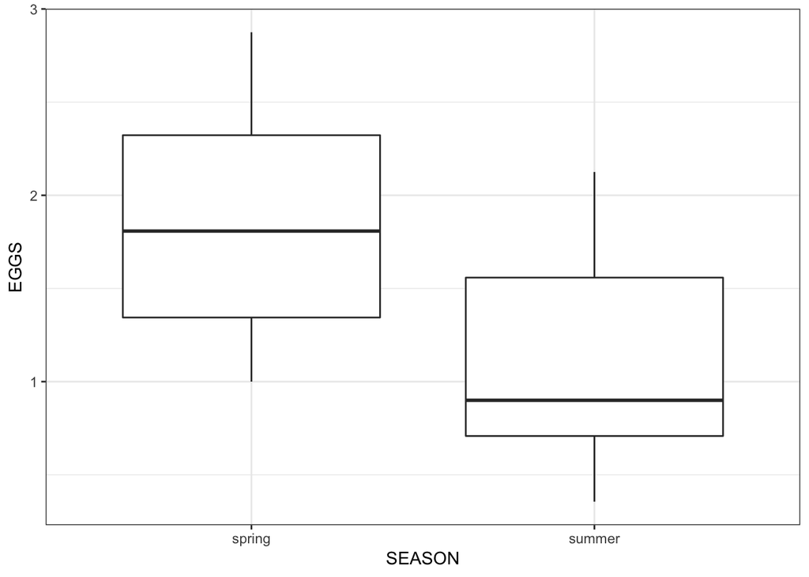

```r
ggplot(data = limpets) +
  geom_boxplot(aes(x = SEASON, y = EGGS)) +
  theme_bw()
```

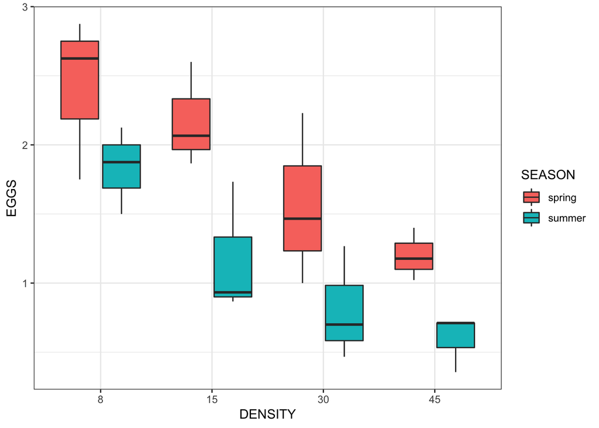

```r
ggplot(data = limpets) +
  geom_boxplot(aes(x = DENSITY, y = EGGS, fill = SEASON)) +
  theme_bw()
```

And let’s run the model.

```r
limpets_lm <- lm(data = limpets, formula = EGGS ~ SEASON * DENSITY)
summary(limpets_lm)
```

```
##
## Call:
## lm(formula = EGGS ~ SEASON * DENSITY, data = limpets)
##
## Residuals:
##     Min      1Q  Median      3Q     Max
## -0.6667 -0.2612 -0.0610  0.2292  0.6647
##
## Coefficients:
##                        Estimate Std. Error t value Pr(>|t|)
## (Intercept)             2.41667    0.24642   9.807  3.6e-08 ***
## SEASONsummer           -0.58333    0.34849  -1.674  0.11358
## DENSITY15              -0.23933    0.34849  -0.687  0.50206
## DENSITY30              -0.85133    0.34849  -2.443  0.02655 *
## DENSITY45              -1.21700    0.34849  -3.492  0.00301 **
## SEASONsummer:DENSITY15 -0.41633    0.49284  -0.845  0.41069
## SEASONsummer:DENSITY30 -0.17067    0.49284  -0.346  0.73363
## SEASONsummer:DENSITY45 -0.02367    0.49284  -0.048  0.96229
## ---
## Signif. codes:  0 '***' 0.001 '**' 0.01 '*' 0.05 '.' 0.1 ' ' 1
##
## Residual standard error: 0.4268 on 16 degrees of freedom
## Multiple R-squared:  0.749,  Adjusted R-squared:  0.6392
## F-statistic: 6.822 on 7 and 16 DF,  p-value: 0.000745
```

```r
anova(limpets_lm)
```

```
## Analysis of Variance Table
##
## Response: EGGS
##                Df Sum Sq Mean Sq F value    Pr(>F)
## SEASON          1 3.2502  3.2502 17.8419 0.0006453 ***
## DENSITY         3 5.2841  1.7614  9.6691 0.0007041 ***
## SEASON:DENSITY  3 0.1647  0.0549  0.3014 0.8239545
## Residuals      16 2.9146  0.1822
## ---
## Signif. codes:  0 '***' 0.001 '**' 0.01 '*' 0.05 '.' 0.1 ' ' 1
```

## Example - Two factor fixed effects model

From Logan 2010, p. 338:

> Quinn (1988) also manipulated the density of larger adults limpets further down the shoreline within enclosures (6, 12 and 24 individuals per enclosure) during the two seasons (winter-spring and summer-autumn) so as to investigate their effects on egg mass production. Again, three replicate enclosures per density/season combination were used, and both density and season were considered fixed factors (from Box 9.4 of Quinn and Keough (2002))

```r
#limpets1 <- read.csv(file = "https://mlammens.github.io/ENS-623-Research-Stats/data/Logan_Examples/Chapter12/Data/quinn1.csv")
limpets1 <- read.csv(file = "https://bit.ly/2DyOB50")

head(limpets1)
```

```
##   DENSITY SEASON  EGGS
## 1       6 spring 1.167
## 2       6 spring 0.500
## 3       6 spring 1.667
## 4       6 summer 4.000
## 5       6 summer 3.830
## 6       6 summer 3.830
```

```r
summary(limpets1)
```

```
##     DENSITY      SEASON       EGGS
##  Min.   : 6   spring:9   Min.   :0.5000
##  1st Qu.: 6   summer:9   1st Qu.:0.8748
##  Median :12              Median :1.6485
##  Mean   :14              Mean   :1.9484
##  3rd Qu.:24              3rd Qu.:2.7075
##  Max.   :24              Max.   :4.0000
```

```r
limpets1$DENSITY <- factor(limpets1$DENSITY)
summary(limpets1)
```

```
##  DENSITY    SEASON       EGGS
##  6 :6    spring:9   Min.   :0.5000
##  12:6    summer:9   1st Qu.:0.8748
##  24:6               Median :1.6485
##                     Mean   :1.9484
##                     3rd Qu.:2.7075
##                     Max.   :4.0000
```

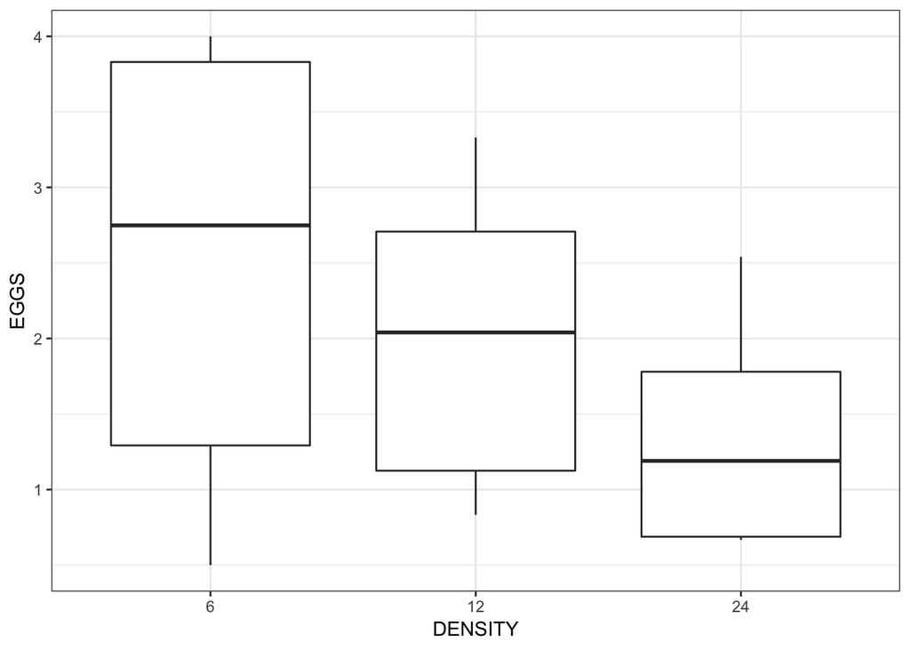

```r
ggplot(data = limpets1) +
  geom_boxplot(aes(x = DENSITY, y = EGGS)) +
  theme_bw()
```

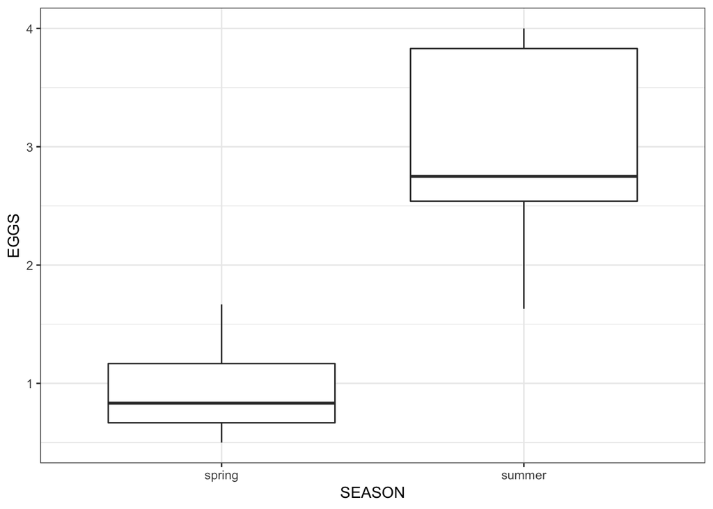

```r
ggplot(data = limpets1) +
  geom_boxplot(aes(x = SEASON, y = EGGS)) +
  theme_bw()
```

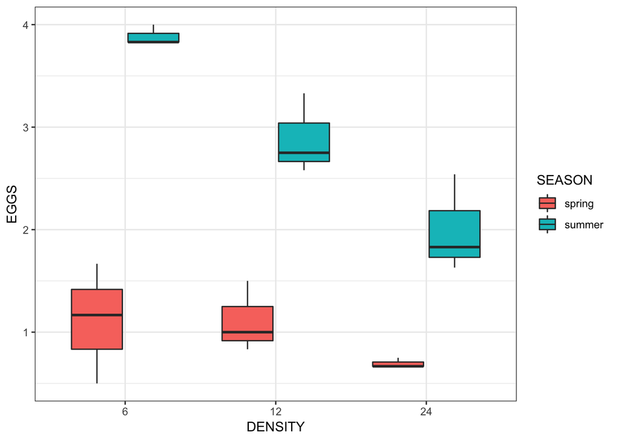

```r
ggplot(data = limpets1) +
  geom_boxplot(aes(x = DENSITY, y = EGGS, fill = SEASON)) +
  theme_bw()
```

And let’s run the model.

```r
limpets1_lm <- lm(data = limpets1, formula = EGGS ~ SEASON * DENSITY)
summary(limpets1_lm)
```

```
##
## Call:
## lm(formula = EGGS ~ SEASON * DENSITY, data = limpets1)
##
## Residuals:
##      Min       1Q   Median       3Q      Max
## -0.61133 -0.16167 -0.04217  0.09892  0.55567
##
## Coefficients:
##                          Estimate Std. Error t value Pr(>|t|)
## (Intercept)             1.1113333  0.2183934   5.089 0.000267 ***
## SEASONsummer            2.7753333  0.3088549   8.986 1.12e-06 ***
## DENSITY12              -0.0003333  0.3088549  -0.001 0.999157
## DENSITY24              -0.4166667  0.3088549  -1.349 0.202221
## SEASONsummer:DENSITY12 -0.9996667  0.4367868  -2.289 0.041029 *
## SEASONsummer:DENSITY24 -1.4700000  0.4367868  -3.365 0.005617 **
## ---
## Signif. codes:  0 '***' 0.001 '**' 0.01 '*' 0.05 '.' 0.1 ' ' 1
##
## Residual standard error: 0.3783 on 12 degrees of freedom
## Multiple R-squared:  0.9301, Adjusted R-squared:  0.9009
## F-statistic: 31.93 on 5 and 12 DF,  p-value: 1.561e-06
```

```r
anova(limpets1_lm)
```

```
## Analysis of Variance Table
##
## Response: EGGS
##                Df  Sum Sq Mean Sq F value    Pr(>F)
## SEASON          1 17.1483 17.1483 119.845 1.336e-07 ***
## DENSITY         2  4.0019  2.0010  13.984 0.0007325 ***
## SEASON:DENSITY  2  1.6907  0.8454   5.908 0.0163632 *
## Residuals      12  1.7170  0.1431
## ---
## Signif. codes:  0 '***' 0.001 '**' 0.01 '*' 0.05 '.' 0.1 ' ' 1
```

### Problems from unbalanced design

See Logan Fig 12.3, p. 325. The variance in a model is “explained” sequentially.

Provided there’s time, we’ll play with the models above.